# An Introduction to Statistical Learning (2013)

Solutions to Exercises

by Brian Hassett

# Chapter 9 Conceptual Exercises

This notebook outlines solutions to the conceptual exercises in Chapter 9 of **An Introduction to Statistical Learning** (James et al. (2013)[^1]).

## Exercise 1

*This problem involves hyperplanes in two dimensions.*

1. *Sketch the hyperplane $1 + 3X_1 − X_2 = 0$. Indicate the set of points for which $1 + 3X_1 − X_2 > 0$, as well as the set of points for which $1 + 3X_1 − X_2 < 0$.*
2. *On the same plot, sketch the hyperplane $−2 + X_1 + 2X_2 = 0$. Indicate the set of points for which $−2 + X_1 + 2X_2 > 0$, as well as the set of points for which $−2 + X_1 + 2X_2 < 0$.*

### (a)

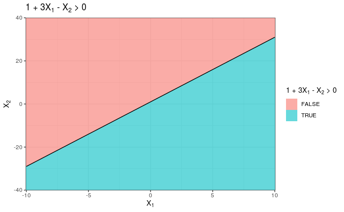

### (b)

Plot the function separately first:

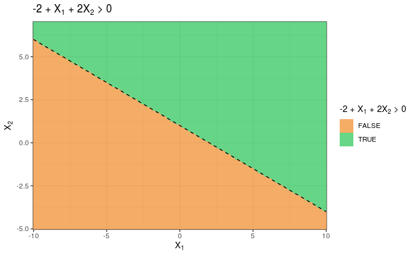

Now plot both on the same plot:

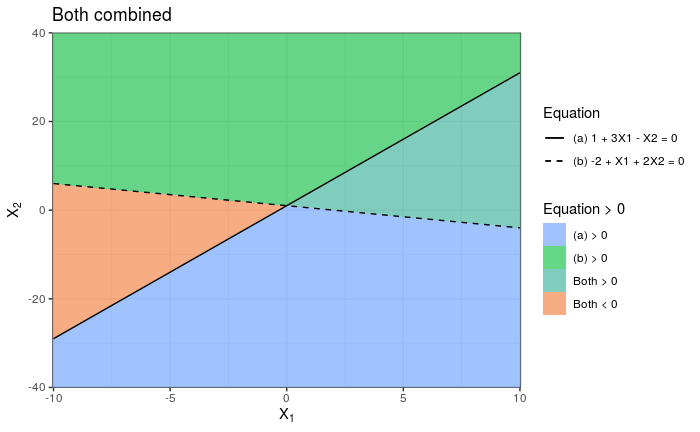

View plots side by side:

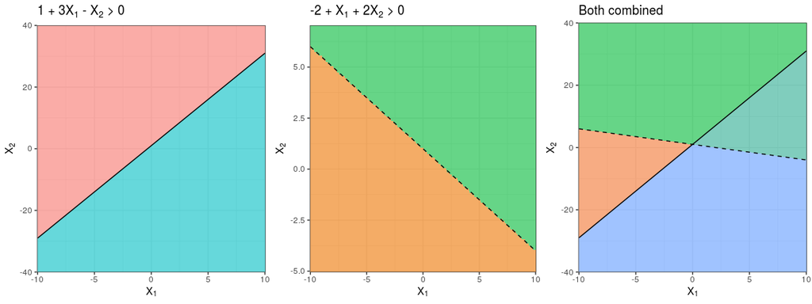

## Exercise 2

*We have seen that in $p = 2$ dimensions, a linear decision boundary takes the form $\beta_0 + \beta_1X_1 + \beta_2X_2 = 0$. We now investigate a non-linear decision boundary.*

1. *Sketch the curve*
   $$(1 + X_1)^2 + (2 − X_2 )^2 = 4.$$
2. *On your sketch, indicate the set of points for which*
   $$(1 + X_1)^2 + (2 − X_2)^2 > 4,$$
   *as well as the set of points for which*
   $$(1 + X_1)^2 + (2 − X_2)^2 \le 4.$$
3. *Suppose that a classifier assigns an observation to the blue class if*
   $$(1 + X_1)^2 + (2 − X_2)^2 > 4,$$
   *and to the red class otherwise. To what class is the observation $(0, 0)$ classified? $(−1, 1)$? $(2, 2)$? $(3, 8)$?*
4. *Argue that while the decision boundary in (c) is not linear in terms of $X_1$ and $X_2$, it is linear in terms of $X_1$, $X_1^2$, $X_2$, and $X_2^2$.*

### Preliminaries:

This decision boundary is a circle with equation:
$$\left(1+X_{1}\right)^{2}+\left(2-X_{2}\right)^{2}=4$$

The center is $(-1, 2)$, the radius is 2.

### (a)

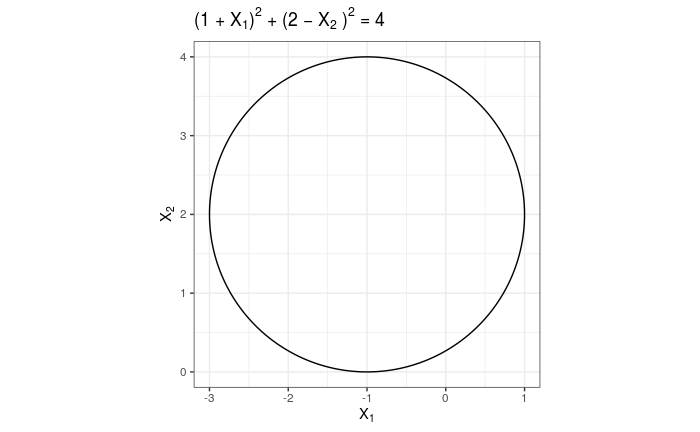

```r
# https://stackoverflow.com/a/6863490
circleFun <- function(center = c(0,0),diameter = 1, npoints = 100){
    r = diameter / 2
    tt <- seq(0,2*pi,length.out = npoints)
    xx <- center[1] + r * cos(tt)
    yy <- center[2] + r * sin(tt)
    return(data.frame(X1 = xx, X2 = yy))
}

curve <- circleFun(c(-1, 2), 4, npoints = 1000)

ggplot() +
  geom_path(data = curve, aes(X1, X2)) +
  theme_bw() +
  labs(x = TeX("X_1"), y = TeX("X_2"),
       title = TeX("(1 + X_1)^2 + (2 − X_2 )^2 = 4")) +
  coord_fixed()
```

### (b)

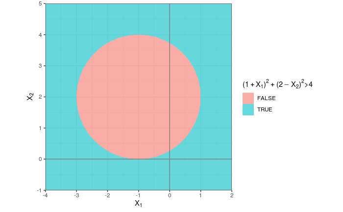

```r
grid <- expand.grid(seq(-4, 4, by = 0.01), seq(-1, 10, by = 0.01))
names(grid) <- c("X1", "X2")
grid$class <- (1 + grid$X1)^2 + (2 - grid$X2)^2 > 4

p1 <- ggplot(grid, aes(X1, X2)) +
  geom_raster(data = grid, aes(X1, X2, fill = class), alpha = 0.6) +
  scale_x_continuous(limits = c(-4, 2), expand = c(0, 0)) +
  scale_y_continuous(limits = c(-1, 5), expand = c(0, 0)) +
  geom_hline(aes(yintercept = 0), color = "grey50") + # x-axis
  geom_vline(aes(xintercept = 0), color = "grey50") + # y-axis
  labs(x = TeX("X_1"), y = TeX("X_2")) +
  scale_fill_discrete(TeX("$(1 + X_1)^2 + (2 - X_2)^2 > 4$")) +
  theme_bw() +
  coord_fixed()
p1
```

### (c)

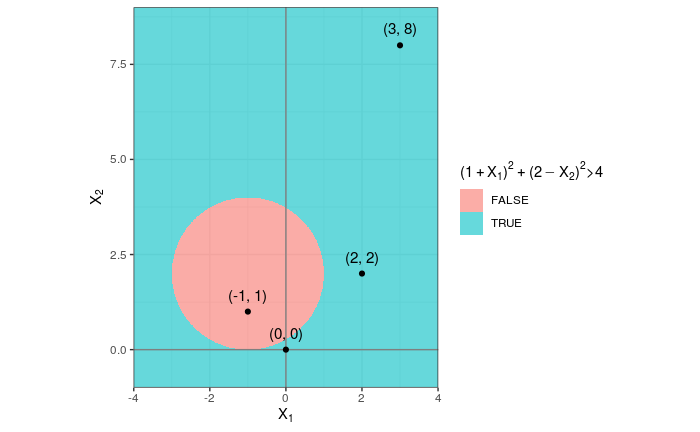

$(0, 0)$, $(2, 2)$ and $(3, 8)$ are in the blue class. $(-1, 1)$ is in the red class.

### (d)

$$\left(1+X_{1}\right)^{2}+\left(2-X_{2}\right)^{2}=4$$
$$\left(1+2X_{1} + X_1^2\right) + \left(4 - 4X_{2} + X_2^2\right) = 4$$
$$X_1^2 + X_2^2 + 2X_{1} - 4X_{2} + 1 = 0$$
$$aX_1^2 + bX_2^2 + cX_{1} + dX_{2} + e = 0,$$
where
$$a = 1;~ b = 1;~ c = 2;~ d = -4;~ e = 1$$
Rewriting the equation for the decision boundary in the above form shows that it can be written as a linear combination of $X_{1}$, $X_{1}^{2}$, $X_{2}$, and $X_{2}^{2}$.

## Exercise 3

*Here we explore the maximal margin classifier on a toy data set.*

1. *We are given $n = 7$ observations in $p = 2$ dimensions. For each observation, there is an associated class label.*
   $$\begin{array}{rlll}{\text { Obs. }} & {X_{1}} & {X_{2}} & {Y} \\ \hline 1 & {3} & {4} & {\text { Red }} \\ {2} & {2} & {2} & {\text { Red }} \\ {3} & {4} & {4} & {\text { Red }} \\ {4} & {1} & {4} & {\text { Red }} \\ {5} & {2} & {1} & {\text { Blue }} \\ {6} & {4} & {3} & {\text { Blue }} \\ {7} & {4} & {1} & {\text { Blue }} \\ \hline\end{array}$$
   *Sketch the observations.*
2. *Sketch the optimal separating hyperplane, and provide the equation for this hyperplane (of the form (9.1)).*
3. *Describe the classification rule for the maximal margin classifier. It should be something along the lines of “Classify to Red if $\beta_0 + \beta_1X_1 + \beta_2X_2 > 0$, and classify to Blue otherwise.” Provide the values for $\beta_0$, $\beta_1$, and $\beta_2$.*
4. *On your sketch, indicate the margin for the maximal margin hyperplane.*
5. *Indicate the support vectors for the maximal margin classifier.*
6. *Argue that a slight movement of the seventh observation would not affect the maximal margin hyperplane.*
7. *Sketch a hyperplane that is not the optimal separating hyperplane, and provide the equation for this hyperplane.*
8. *Draw an additional observation on the plot so that the two classes are no longer separable by a hyperplane.*

### (a)

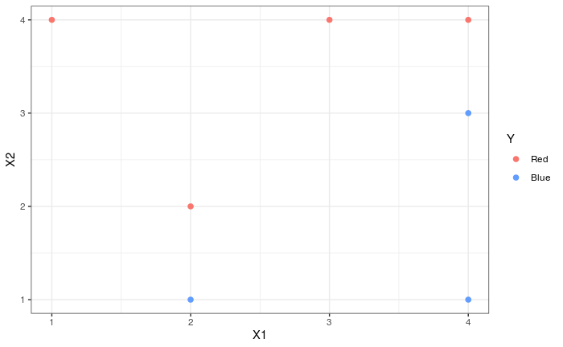

```r
df <- data.frame(X1 = c(3, 2, 4, 1, 2, 4, 4),
                 X2 = c(4, 2, 4, 4, 1, 3, 1),
                 Y =  c("Red", "Red", "Red", "Red", "Blue", "Blue", "Blue"))

cols <- c("Red" = "#F8766D", "Blue" = "#619CFF")
ggplot(df) +
  geom_point(aes(X1, X2, color = Y), size = 2) +
  scale_color_manual(values = cols) +
  theme_bw() +
  guides(color = guide_legend(reverse = TRUE))
```

### (b)

The points $(2, 1.5)$ and $(4, 3.5)$ are half way between the two pairs of closest points from each class. The optimal hyperplane will intersect these two points. The slope of this line ($m$) is:

$$m = \frac{y_2 - y_1}{x_2 - x_1}$$
$$m = \frac{3.5 - 1.5}{4 - 2}$$
$$m = 1$$

The $y$-intercept (or $X2$-intercept), $y_0$, is:
$$y_0 = y - mx$$
Sub in $m$ and the values for one of the points, $(2, 1.5)$:

$$\begin{aligned}
y_0 &= (1.5) - (1)(2) \\
y_0 &= -0.5
\end{aligned}$$

Using these values for $m$ and $y_0$ we can add the line to the plot:

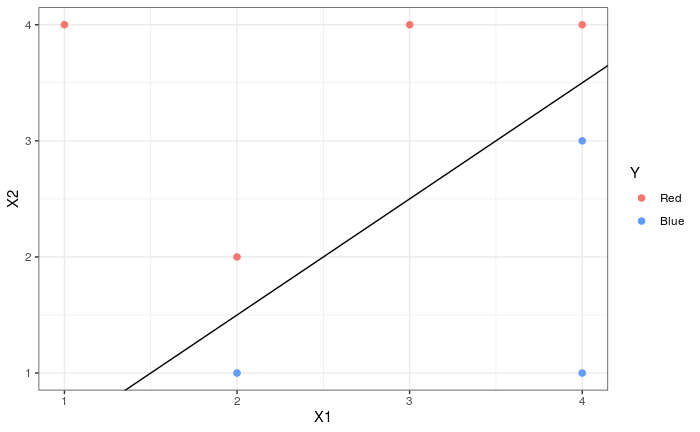

```r
ggplot(df) +
  geom_point(aes(X1, X2, color = Y), size = 2) +
  geom_abline(aes(slope = 1, intercept = -0.5)) +
  scale_color_manual(values = cols) +
  theme_bw() +
  guides(color = guide_legend(reverse = TRUE))
```

We require the equation of the hyperplane in the below form.
$$\beta_{0}+\beta_{1} X_{1}+\beta_{2} X_{2}=0 \hspace{2cm} (9.1)$$

We can rewrite our above equation in terms of $\beta$-coefficients and $X_1$ and $X_2$:

$$y_0 + mx - y = 0 \equiv \beta_{0}+\beta_{1} X_{1}+\beta_{2} X_{2}=0,$$
where
$$\begin{aligned}
\beta_0 &= y_0 = -0.5, \\ \beta_1 &= m = 1, \\ \beta_2 &= -1 .
\end{aligned}$$

This gives us our equation of the hyperplane:
$$-0.5 + X_1 - X_2 = 0$$

### (d)

The margins for the maximal margin hyperplane will intersect the points closest to the hyperplane. The margins have the same slope, $m$, as the hyperplane. The intercepts are $(2) - (1)(2) = 0$ for the margin that goes through $(2, 2)$, and $(1) - (1)(2) = -1$ for the margin that goes through $(2, 1)$:

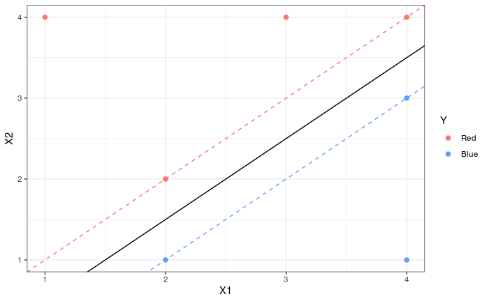

```r
ggplot(df) +
  geom_point(aes(X1, X2, color = Y), size = 2) +
  geom_abline(aes(slope = 1, intercept = -0.5)) +
  geom_abline(aes(slope = 1, intercept = 0), color = "#F8766D", linetype = "dashed") +
  geom_abline(aes(slope = 1, intercept = -1), color = "#619CFF", linetype = "dashed") +
  scale_color_manual(values = cols) +
  theme_bw() +
  guides(color = guide_legend(reverse = TRUE))
```

### (e)

The support vectors are marked on the plot with an ‘x’:

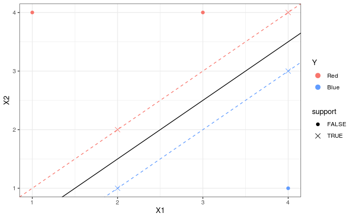

```r
df$support <- c(FALSE, TRUE, TRUE, FALSE, TRUE, TRUE, FALSE)
shapes <- c(20, 4)

ggplot(df) +
  geom_point(aes(X1, X2, color = Y, shape = support), size = 3) +
  geom_abline(aes(slope = 1, intercept = -0.5)) +
  geom_abline(aes(slope = 1, intercept = 0), color = "#F8766D", linetype = "dashed") +
  geom_abline(aes(slope = 1, intercept = -1), color = "#619CFF", linetype = "dashed") +
  scale_color_manual(values = cols) +
  scale_shape_manual(values = shapes) +
  theme_bw() +
  guides(color = guide_legend(reverse = TRUE)) #+  guides(shape = guide_legend(legend.position = "none"))
```

### (f)

The seventh observation, $(4, 1)$, is not a support vector, and can move anywhere within the blue shaded region without having an effect on the maximal margin hyperplane:

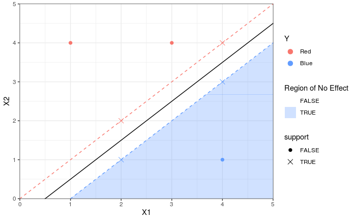

```r
grid <- expand.grid(seq(0, 5, by = 0.01), seq(0, 5, by = 0.01))
names(grid) <- c("X1", "X2")
grid$region <- (-1 + grid$X1 - grid$X2 > 0)

tiles <- c(NA, '#619CFF')
ggplot(df) +
  geom_tile(data = grid, aes(X1, X2, fill = region), alpha = 0.3) +
  scale_fill_manual(name = "Region of No Effect", values = tiles) +
  geom_point(aes(X1, X2, color = Y, shape = support), size = 3) +
  geom_abline(aes(slope = 1, intercept = -0.5)) +
  geom_abline(aes(slope = 1, intercept = 0), color = "#F8766D", linetype = "dashed") +
  geom_abline(aes(slope = 1, intercept = -1), color = "#619CFF", linetype = "dashed") +
  scale_color_manual(values = cols) +
  scale_shape_manual(values = shapes) +
  scale_x_continuous(expand = c(0, 0)) +
  scale_y_continuous(expand = c(0, 0)) +
  theme_bw() +
  guides(color = guide_legend(reverse = TRUE)) #+ #guides(shape = guide_legend(legend.position = "none"))
```

### (g)

Any line that is not the hyperplane we have drawn will be suboptimal. Draw a line with the same slope but a different $y$-intercept of 1, whose equation is $1 + X_1 - X_2 = 0$:

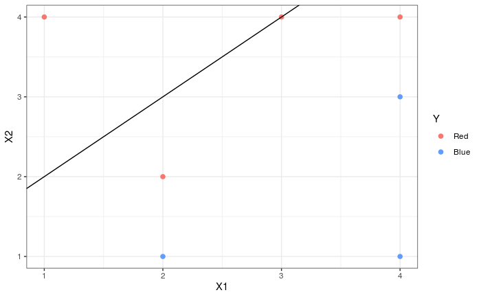

```r
ggplot(df) +
  geom_point(aes(X1, X2, color = Y), size = 2) +
  geom_abline(aes(slope = 1, intercept = 1)) +
  scale_color_manual(values = cols) +
  theme_bw() +
  guides(color = guide_legend(reverse = TRUE))
```

We can see that this line no longer separates the observations by class.

### (h)

An additional point that falls on the far side of the margin *opposite* to that of its class will mean the data is no longer separable by a hyperplane. Add a new observation so that it falls into the red region defined by the hyperplane in the above plots, but which is assigned a class of Blue:

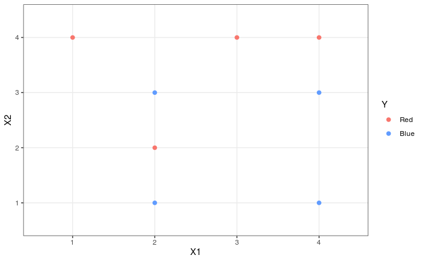

```r
df[nrow(df) + 1, ] <- c(2, 3, "Blue", FALSE)

ggplot(df) +
  geom_point(aes(X1, X2, color = Y), size = 2) +
  scale_color_manual(values = cols) +
  theme_bw() +
  guides(color = guide_legend(reverse = TRUE))
```

Now the data can no longer be separated by a hyperplane.

[^1]: James G, Witten D, Hastie T, Tibshirani R (2013). *An Introduction to Statistical Learning: with Applications in R*. Springer, 1st edition.